# Forschungspraktikum 1+2: Computational Social Science

Session 01: Welcome & Introduction

Dr. Christian Czymara

## Agenda

- Introduction & course structure
- Term paper
- Software, introduction to R (and Python)

# Introduction

## Lecturer

- Lecturer at the Department of Sociology with a Focus on Methods of Quantitative Empirical Social Research
- Research interests: Migration & integration, inter-group conflict, attitudes, mass media, political communication
- Methods: Classical quantitative methods for social research combined with computational methods and natural language processing
- More info on my [homepage](https://czymara.com/)

## Office Hours

- After appointment
- Office: 3.G152 (PEG)
- Contact me at cc@soz.uni-frankfurt.de
- Do not hesitate to write me if you have questions, comments, doubts, criticism etc.

## General information

- Thursdays, 14:15 in room PEG 2.G 111 / 116
- Material available on [GitHub](https://github.com/czymaracourses/CSS)
- Join this course’s [mailing list](https://dlist.server.uni-frankfurt.de/mailman/listinfo/Czymara-fopra) for communication
- Course on [QIS](https://qis.server.uni-frankfurt.de/qisserver/rds?state=verpublish&status=init&vmfile=no&publishid=383699&moduleCall=webInfo&publishConfFile=webInfo&publishSubDir=veranstaltung)
- Slides in English, Kurs auf Deutsch 🙂

# Overview

## What is CSS?

- *“The intersection of social science and data science is sometimes called computational social science.”* (Salganik 2018: xviii)
- Answer social science questions with computer science methods
- New, “big” data sources
- New methods, much more computational power
- In particular, text mining and natural language processing (NLP) have received increasing attention in the social sciences

## Definining big

- 3 Vs: Volume, Variety, Velocity
- A lot of data…
- In a variety of formats…
- Being created constantly

## The boom of CSS and NLP

- [Books Ngram Viewer](https://books.google.com/ngrams/graph?content=computational+social+science%2Ctext+mining%2Cnatural+language+processing&year_start=2000&year_end=2022&corpus=en&smoothing=3&case_insensitive=true)
- “Google Books Ngram Viewer, it displays a graph showing how those phrases have occurred in a corpus of books” [google.com](https://books.google.com/ngrams/info)

## Goal of seminar

- The goal is that students learn how to use computational tools to analyze big and small data
- The training will focus on R, but we might work with Python from time to time
- This implies continuous work throughout the semester

## You should have…

- Interest in quantitative social research and programming
- Good working knowledge of descriptive and inductive statistics (regression etc.)
- Some knowledge of R or another statistics software / language
- I will introduce both in this seminar, but the focus will be on computational methods

## Your interest

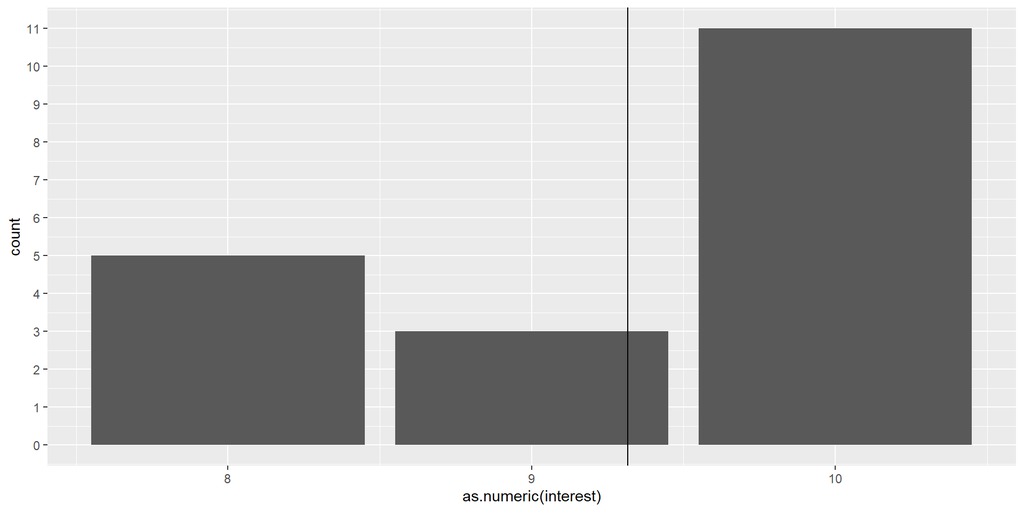

Average motivation is: 9.3157895/10

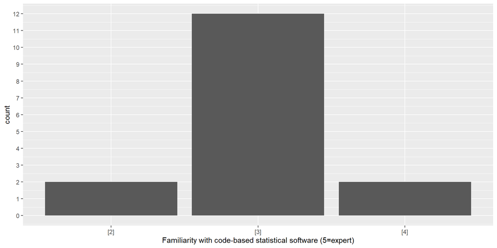

## Prior knowledge CSS

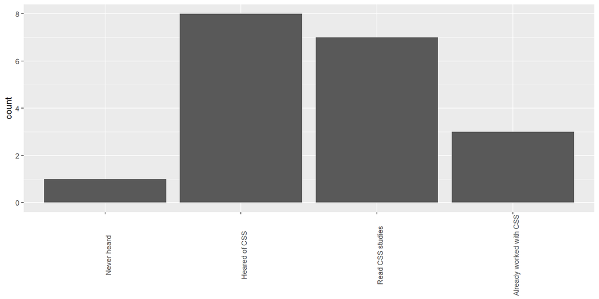

## Other prior knowledge

- Percentage who ran a logistic regression before: 0.8421053
- Percentage who used machine learning before: 0.2631579
- Average experience with code-based data analysis: 3/5
- Percentage who usually work with R: 0.5263158
- Percentage who usually work with Python: 0.2631579
- Percentage who never use any statistical software: NA

## Your expectations (selection)

```
[1] "Ich wünsche mir, dass die Anforderungen an die Student*innen von Anfang klar kommuniziert werden bezüglich des Levels, das wir uns bei R (möglicherweise noch vor dem Kurs) selbst aneignen müssen und wie die Teilnahmenachweise und Leistungsnachweise erbracht werden."
```

## Your expectations (selection)

```
[1] "Textanalysen von Internetquellen bzw. Textdokumenten (politische Positionspapiere), sofern  dies in den betreffenden Methoden enthalten ist. Jedenfalls verstehe ich dies so."
```

```
[1] "My personal main area of interest lies with text mining / natural language processing methods. I am especially interested of running analysis with something like sentiment analyis as I learned how to do it in my BA, but never got around to do it in earnest."
```

```
[1] "Ich habe schon einiges an linearen und log regressionen ausgeführt und würde meinen Werkzeugkasten gerne erweitern. Am liebsten würde ich weiterhin in R arbeiten."
```

```
[1] "Ich habe Kenntnisse in Statistik und bereits Erfahrungen mit Python gemacht, allerdings weiß ich noch nicht genau mit welchen Methoden beides kombieniert werden kann. Daher würde mich insbesondere der methodisch-soziologische Bezugspunkt interessieren."
```

## Your expectations (selection)

```
[1] "I am wondering how to get access to \"big\" data. Social science data is often very limited so I am still wondering how to apply machine learning for social phenomena"
```

## What this course will offer

- A guide to the scraping, preparation, and analysis of different types of digital trace data (focus on text-as-data)
- The means to conduct your own computational research project
- Hands-on application of methods in tutorials

## What this course will not offer

- In-depth understanding of mathematical foundation of methods
- Advanced programming
- Course is not suited as a general introduction to quantitative social science methods

## Literature

- See GitHub syllabus for literature on individual sessions
- Van Atteveldt, W., Trilling, D., & Calderon, C. A. (2022). [Computational analysis of communication](https://cssbook.net/).
- Salganik, M. J. (2019). [Bit by bit: Social research in the digital age](https://www.bitbybitbook.com/). Princeton University Press.

# Term paper

## Term paper

- Computational analysis of digital data (in the broadest sense) on a research question of your interest
- You can choose from any topic (… for which you find suitable data)
- The focus of the paper should be the analysis

## Term paper

- ~15 to 20 pages, incl. tables, graphs, references etc.
- Also add your code so that I can understand and reproduce what you’ve done
- *DEADLINE IS 01 APRIL 2025!*
- Hand in as PDF and code via e-mail to cc@soz.uni-frankfurt.de

# Syllabus

## Syllabus overview

| Session | Date | Topic |
| --- | --- | --- |
| 1 | 17. Okt 24 | Introduction |
| 2 | 24. Okt 24 | Text-As-Data: Preparation |
| 3 | 31. Okt 24 | Text-As-Data: Frequency Analysis |

## Syllabus overview

| Session | Date | Topic |
| --- | --- | --- |
| 4 | 07. Nov 24 | Sentiment Analysis |
| 5 | 14. Nov 24 | Machine Learning I |
| 6 | 21. Nov 24 | Machine Learning II |

## Syllabus overview

| Session | Date | Topic |
| --- | --- | --- |
| 7 | 28. Nov 24 | Topic Modeling |
| 8 | 05. Dez 24 | Advanced Topic Modeling |

## Syllabus overview

| Session | Date | Topic |
| --- | --- | --- |
| 9 | 12. Dez 24 | Web scraping |
| 10 | 19. Dez 24 | Individual data collection |
|  | Christmas break |  |

## Syllabus overview

| Session | Date | Topic |
| --- | --- | --- |
| 11 | 16. Jan 25 | Open Science |
| 12 | 23. Jan 25 | Large language models |
| 13 | 30. Jan 25 | Using Google and Amazon Web Services |

## Syllabus overview

| Session | Date | Topic |
| --- | --- | --- |
| 14 | 06. Feb 25 | Presentation of term papers |
| 15 | 13. Feb 25 | Course Wrap-Up |

More information about each session on [GitHub](https://github.com/czymaracourses/CSS?tab=readme-ov-file#syllabus)

# Questions or comments?

## Data collection

- Download data sets from websites, online archives, repositories, …
- Application Programming Interfaces (APIs)
- Web scraping
- Collect your own data

## Data analysis

- Sentiment analysis
- Text summary
- Machine translation
- Classification
- Regression etc.

## Text analysis

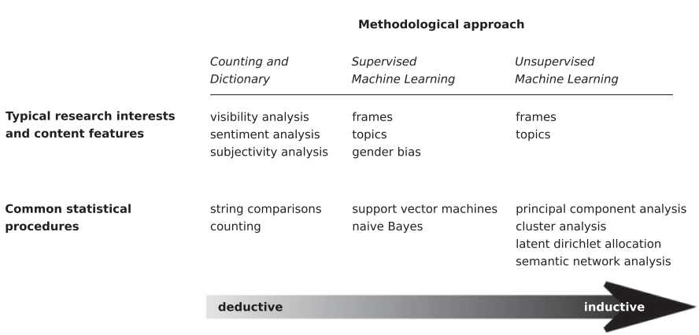

[Boumans & Trilling(2016)](https://www.tandfonline.com/doi/full/10.1080/21670811.2015.1096598)

# A glimpse into computational social science research

## Example 1

[Political migration discourses on social media: a comparative perspective on visibility and sentiment across political Facebook accounts in Europe](https://www.tandfonline.com/doi/full/10.1080/1369183X.2019.1665990)

## Example 2

[Real-World Developments Predict Immigration News in Right-Wing Media: Evidence from Germany](https://www.tandfonline.com/doi/full/10.1080/15205436.2023.2240307)

## Example 3

[The rise of Jihadist propaganda on social networks](https://link.springer.com/article/10.1007/s42001-018-0015-z)

## Example 4

[Online hatred of women in the Incels.me forum Linguistic analysis and automatic detection](https://www.jbe-platform.com/content/journals/10.1075/jlac.00026.jak)

# Software

## R

- You will need R for most tutorials and the term paper (Python use is encouraged as well)
- To work with R, install on your computers
- R at [cloud.r-project.org](https://cloud.r-project.org/)
- RStudio at [rstudio.com](https://www.rstudio.com/products/rstudio/download/)

## Python

- To work with Python, install on your computers
- Python at [python.org](https://www.python.org/downloads/)
- Anaconda at [anaconda.com](https://www.anaconda.com/products/distribution) (email required)
- Important: Python does not like white spaces in your file path (i.e. “C:\Users\Christian Czymara\”)

## GitHub

- Material will be uploaded on GitHub
- github.com/czymaracourses/CSS
- You can download files without having an account
- For advanced users: Feel free to make an account and download GitHub Desktop to synchronize files every week

## ChatGPT

- Not strictly necessary, but can greatly help you code and solve coding related problems
- Requires a (free) OpenAI account
- In particular, check out [Code Nerd](https://chatgpt.com/g/g-J5futwiVV-code-nerd) (requires ChatGPT Plus subscription)

[figure not shown]

R

## R

- Why “R”?
- “R is an implementation of the S programming language” (Wikipedia)
- R is a programming language for data analysis
- Rstudio is a so called Integrated Development Environment (IDE), making writing and running R code a lot easier
- Overview of stored objects
- Projects containing multiple files
- Git connection
- Etc.

## R benefits

- Free and open source
- Large and very helpful community
- Plethora of user-written packages on basically everything
- Very powerful tools for data manipulation and data visualization
- In addition to analyzing data, you can write programs, websites, books, and much more with R (and R Markdown)
- … and integrate with other languages

## Google Colab

- To understand the basics of R, we will work with [this Google Colab](https://colab.research.google.com/github/czymaracourses/intros/blob/main/Intro_to_R.ipynb)

[figure not shown]

Python

## Google Colab

- To understand the basics of Python, we will work with [another Google Colab](https://colab.research.google.com/github/czymaracourses/intros/blob/main/Intro_to_Python.ipynb)

## *Tasks for next week*

- Install R and Rstudio
- Familiarize with R
- Bring one of your term papers or your BA thesis *in DOCX* format on a USB stick
- Optional: Install Pyhton and Anaconda

## Literature

- The exercise is inspired by [this great intro](https://favstats.github.io/ds3_r_intro/#1) from Fabio Votta
- Wickham & Grolemund (2017). [R for Data Science](https://r4ds.had.co.nz/). O’Reilly